# assignment_2_part_1, Methods 3, 2024

2024-09-19

REMEMBER: In your portfolio, make sure to include code that can reproduce the answers requested in the exercises below (**MAKE A KNITTED VERSION**). If it does not KNIT, it cannot be part of your portfolio

# Exercises and objectives

The objectives of the exercises of this assignment are:  
A) Download and organise the data and model B) Fit multilevel models for response times  
C) Fit multilevel models for binomial data  
D) Fit multilevel models for count data

## Exercise A - Download and organise the data and model

Go to https://osf.io/ecxsj/files/ and download the files associated with Experiment 2 (there should be 29).  
The data is associated with Experiment 2 of the article at the following DOI https://doi.org/10.1016/j.concog.2019.03.007

1. Put the data from all subjects into a single data frame

```r
path <- '/home/lau/Dokumenter/cognitive_science/2021_methods_3/github_methods_3/week_03/private/data' ## exchange for your own path
n.subjects <- 29
for(subject.index in 1:n.subjects)
{
    ## the formatting key for "sprintf" indicates that the output should be an integer (i) prepended by up to 3 leading zeros
    filename <- paste(sprintf('%03i', subject.index), '.csv', sep='')
    full.path <- paste(path, filename, sep='/')
    if(subject.index == 1) data <- read.csv(full.path) else
    {
        data <- rbind(data, read.csv(full.path))
    }
}
```

2. Describe the data and construct extra variables from the existing variables
   1. add a variable to the data frame and call it *correct* (have it be a *logical* variable). Assign a 1 to each row where the subject indicated the correct answer and a 0 to each row where the subject indicated the incorrect answer (**Hint:** the variable *obj.resp* indicates whether the subject answered “even”, *e* or “odd”, *o*, and the variable *target_type* indicates what was actually presented.
   2. describe what the following variables in the data frame contain, *trial.type*, *pas*, *trial*, *target.contrast*, *cue*, *task*, *target_type*, *rt.subj*, *rt.obj*, *obj.resp*, *subject* and *correct*. (That means you can ignore the rest of the variables in your description). For each of them, indicate and argue for what `class` they should be classified into, e.g. *factor*, *numeric* etc., and apply that class!

```r
## i.
logical.check <- (data$target.type == 'even' & data$obj.resp == 'e') |
                 (data$target.type == 'odd'  & data$obj.resp == 'o')
data$correct <- ifelse(logical.check, TRUE, FALSE)

## ii.

data$trial.type      <- factor(data$trial.type)
data$task            <- factor(data$task)
data$pas             <- factor(data$pas) ## one could argue that it should be ordinal
data$trial           <- as.integer(data$trial)
data$target.contrast <- as.numeric(data$target.contrast)
data$cue             <- factor(data$cue)
data$target.type     <- factor(data$target.type)
data$rt.subj         <- as.numeric(data$rt.subj)
data$rt.obj          <- as.numeric(data$rt.obj)
data$obj.resp        <- factor(data$obj.resp)
data$correct         <- as.logical(data$correct)
data$subject         <- factor(data$subject)
```

## Exercise B - Fit multilevel models for response times

We **only** look at the *experiment* trials (*trial.type*)

1. Choose the first four subjects and plot their Quantile-Quantile (Q-Q) plots for the residuals of their objective response times (*rt.obj*) based on four models (one for each subject) where only (first-level) intercept is modelled (use *qqnorm* and *qqline*)
   1. comment on these
   2. does a log-transformation of the response time data improve the Q-Q-plots?

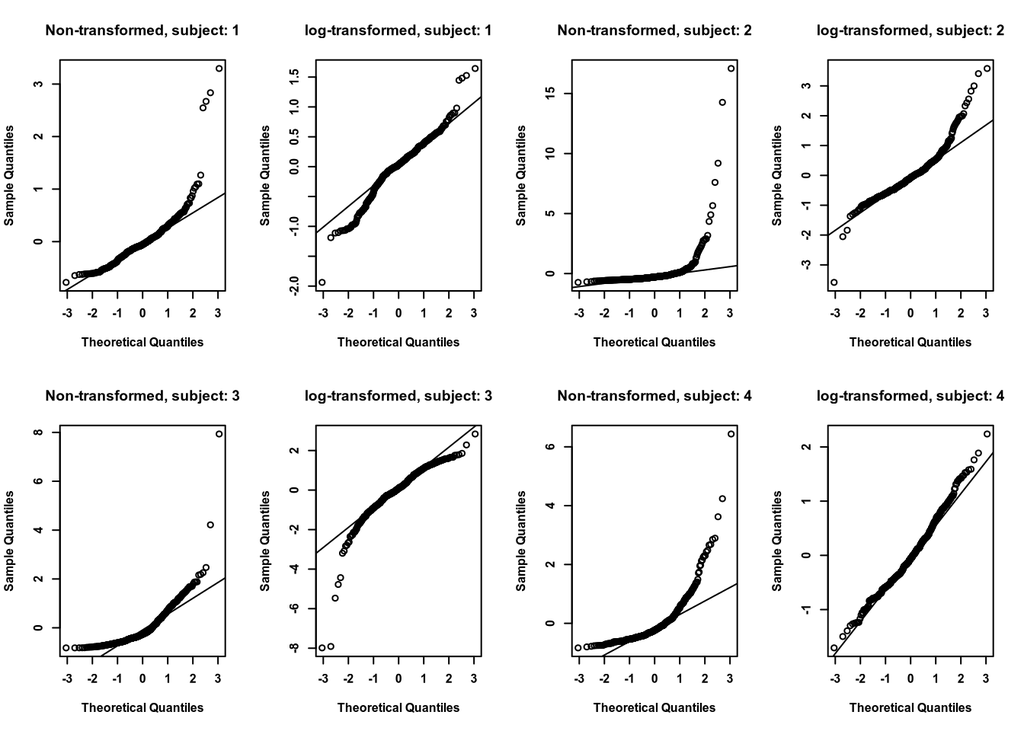

```r
## i.
subjects <- 1:4
par(mfrow=c(2, 4), font.axis=2, font.lab=2, cex=0.5)
for(subject in subjects)
{
    subject.data <- data[data$subject == subject &
                                            data$trial.type == 'experiment', ]
    model <- lm(rt.obj ~ 1, data=subject.data)
    log.model <- lm(log(rt.obj) ~ 1, data=subject.data)

    qqnorm(model$residuals, main=paste('Non-transformed, subject:', subject))
    qqline(model$residuals)

    qqnorm(log.model$residuals,
           main=paste('log-transformed, subject:', subject))
    qqline(log.model$residuals)
}
```

**Answer ii**: log-transforming makes response times more normal, but not a perfect fit

2. Do a partial pooling model modelling objective response times (log-transformed) as dependent on *task* ($X$-matrix), including all subjects
   1. which intercepts (ignore slopes for now) would you include among your second-level effects ($Z$-matrix) and why? Choose from the variables: *pas*, *cue*, *target_type*, *subject* and *correct*
   2. explain in your own words what your chosen model says about response times between the different tasks
   3. now make a model that has second-level intercepts for *obj.resp* and *target_type*: explain why the fit is singular (Hint: read the first paragraph under details in the help for `isSingular`)
   4. in your own words - how could you explain why your model would result in a singular fit? (Draw on the background knowledge from the design of the task)

```r
library(lme4)
## i.

exp.data <- subset(data, data$trial.type == 'experiment')

multilevel.1 <- lmer(log(rt.obj) ~ task + (1 | subject), data=exp.data)
multilevel.2 <- lmer(log(rt.obj) ~ task + (1 | subject) + (1 | cue),
                     data=exp.data)
multilevel.3 <- lmer(log(rt.obj) ~ task + (1 | subject) + (1 | cue) +
                         (1 | target.type),
                     data=exp.data)

multilevel.4 <- lmer(log(rt.obj) ~ task + (1 | subject) + (1 | cue) +
                         (1 | target.type) + (1 | pas),
                     data=exp.data)
multilevel.5 <- lmer(log(rt.obj) ~ task + (1 | subject) + (1 | cue) +
                         (1 | target.type) + (1 | pas) + (1 | correct),
                     data=exp.data) ## I choose this

# ii.
print('Answer ii.: ')
```

```
## [1] "Answer ii.: "
```

```r
# iii.
multilevel.singular <- lmer(log(rt.obj) ~ task +
                         (1 | target.type) + (1 | obj.resp),
                         data=exp.data)
print(VarCorr(multilevel.singular), comp='Variance')
```

```
##  Groups      Name        Variance
##  target.type (Intercept) 0.00000
##  obj.resp    (Intercept) 0.01329
##  Residual                0.78688
```

```r
print('Answer iii.: "target.type" explains zero variance')
```

```
## [1] "Answer iii.: \"target.type\" explains zero variance"
```

```r
# iv.
print('Answer iv.: ')
```

```
## [1] "Answer iv.: "
```

## Exercise C - Fit multilevel models for binomial data

1. Fit a multilevel model that models *correct* as dependent on *task* with a unique intercept for each *subject*
   1. does *task* explain performance?
   2. add *pas* as a main effect on top of *task* - what are the consequences of that?
   3. now fit a multilevel model that models *correct* as dependent on *pas* with a unique intercept for each *subject*
   4. finally, fit a model that models the interaction between *task* and *pas* and their main effect, still with a unique intercept for each *subject*
   5. describe in your own words which model is the best in explaining the variance in accuracy

```r
# i.
multilevel.logistic <- glmer(correct ~ task + (1 | subject), data=exp.data,
                             family='binomial')
# ii.
multilevel.logistic.main <- glmer(correct ~ task + pas + (1 | subject),
                                  data=exp.data, family='binomial')
# iii.

multilevel.logistic.pas <- glmer(correct ~ pas + (1 | subject),
                                 data=exp.data, family='binomial')

# iv.
multilevel.logistic.interaction <- glmer(correct ~ pas * task + (1 | subject),
                                         data=exp.data, family='binomial')

# v.
print('Answer v.:')
```

```
## [1] "Answer v.:"
```

## Exercise D - Fit multilevel models for count data

1. Initialise a new data frame, `data.count`. *count* should indicate the number of times they categorized their experience as *pas* 1-4 for each *task*. I.e. the data frame would have for subject 1: for task:singles, pas1 was used # times, pas2 was used # times, pas3 was used # times and pas4 was used # times. You would then do the same for task:pairs and task:quadruplet

```r
data.count <- data.frame(count = numeric(),
                         pas = numeric(), ## remember to make this into a factor afterwards
                         task = numeric(), ## and this too
                         subject = numeric()) ## and this too

subjects <- 1:29
row.index <- 1
n.pas <- length(levels(data$pas))
for(subject in subjects)
{
    for(task in levels(data$task))
    {
        for(pas in 1:n.pas)
        {
            ## count
            count <- sum(data$subject == subject & data$task == task &
                             data$pas == pas & data$trial.type == 'experiment')
            data.count[row.index, ] <- NA
            data.count$pas[row.index] <- pas
            data.count$task[row.index] <- task
            data.count$subject[row.index] <- subject
            data.count$count[row.index] <- count

            row.index <- row.index + 1
        }
    }
}

data.count <- within(data.count,
                   {
                       pas <- factor(pas, levels = c(1, 2, 3, 4))
                       task <- factor(task, levels = c('singles', 'pairs', 'quadruplet'))
                       subject <- factor(subject)
                   })
```

2. Now fit a multilevel model that models a unique “slope” for *pas* for each *subject* with the interaction between *pas* and *task* and their main effects being modelled
   1. which family should be used?
   2. why is a slope for *pas* not really being modelled, and what are we modelling instead?
   3. if you get a convergence error, try another algorithm (the default is the *Nelder_Mead*) - try (*bobyqa*) for which the `dfoptim` package is needed. In `glmer`, you can add the following for the `control` argument: `glmerControl(optimizer="bobyqa")` (if you are interested, also have a look at the function `allFit`)
   4. when you have a converging fit - fit a model with only the main effects of *pas* and *task*. Compare this with the model that also includes the interaction
   5. indicate which of the two models, you would choose and why
   6. Make a plot with four subplots that shows the estimated amount of ratings, $\hat y$ for four subjects of your choice as compared to the measured count, $y$. Also include the first-level, $X$, response for *pas* (aggregating over *task*).
   7. based on your chosen model and the plot - write a short summary on what this says about the distribution of ratings as dependent on *pas* and *task* and their interaction (you can create plots for all subjects to inform your summary, but only include four subplots in your summary)

```r
## 2)

multilevel.poisson.NM <- glmer(count ~ pas*task + (pas | subject), data=data.count,
                            family='poisson', verbose=FALSE,
                            control=glmerControl(optimizer='Nelder_Mead')) # doesn't converge
# i.
print('Answer i.: The "poisson" family should be used as we are dealing with count data')
```

```
## [1] "Answer i.: The \"poisson\" family should be used as we are dealing with count data"
```

```r
# ii.
print('Answer ii.: Because "pas" is a factorial variable - we are modelling a different average for each subject')
```

```
## [1] "Answer ii.: Because \"pas\" is a factorial variable - we are modelling a different average for each subject"
```

```r
# iii.
multilevel.poisson.bobyqa <- glmer(count ~ pas*task + (pas | subject), data=data.count,
                            family='poisson', verbose=FALSE,
                            control=glmerControl(optimizer='bobyqa'))

# iv.
multilevel.poisson.main.bobyqa <- glmer(count ~ pas+task + (pas | subject), data=data.count,
                            family='poisson', verbose=FALSE,
                            control=glmerControl(optimizer='bobyqa'))

# v.
print('Answer v.: ')
```

```
## [1] "Answer v.: "
```

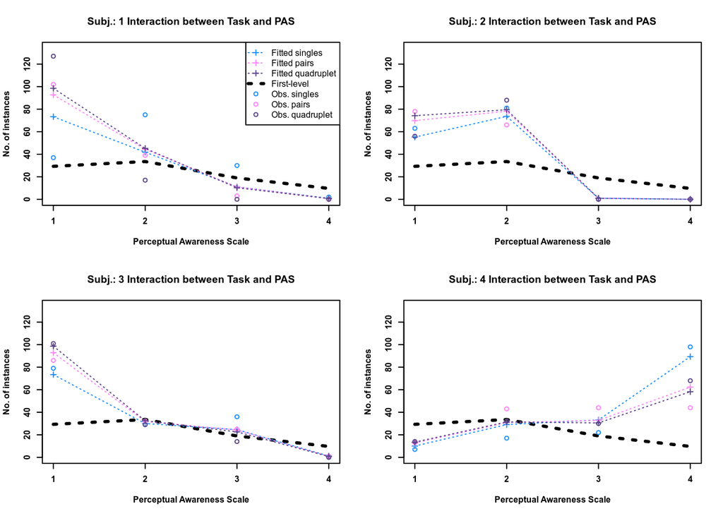

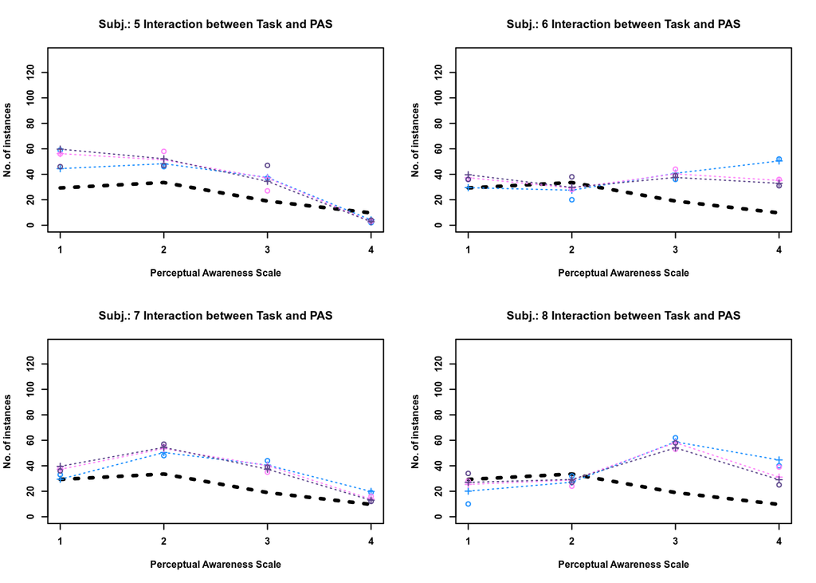

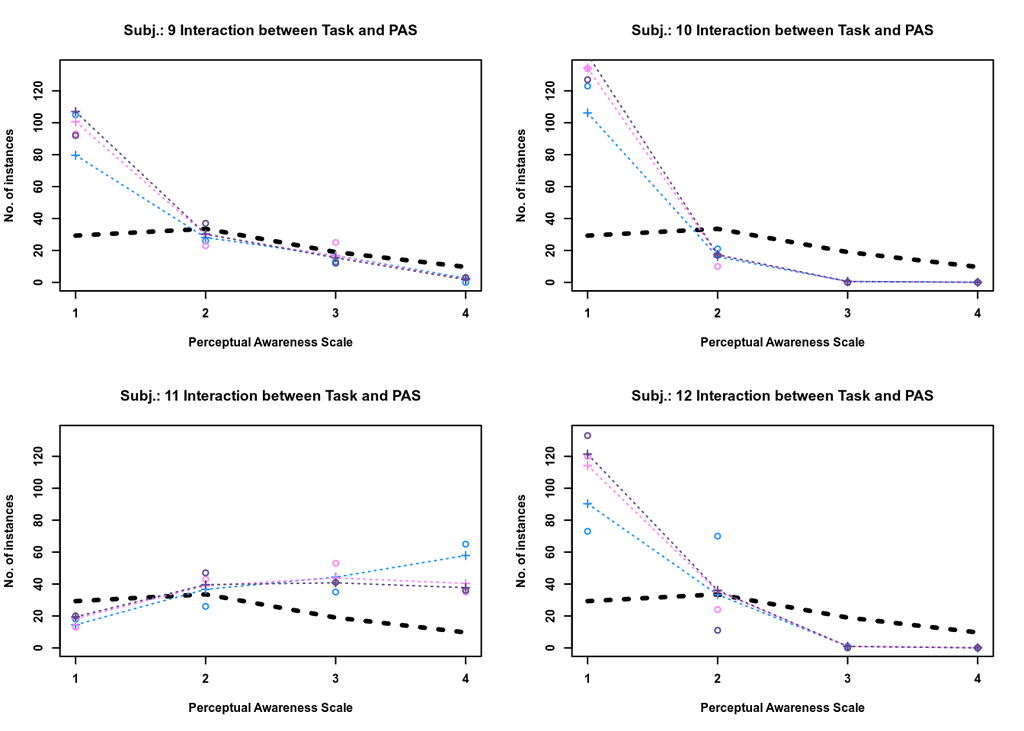

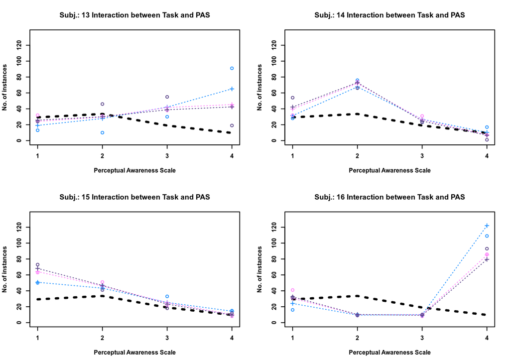

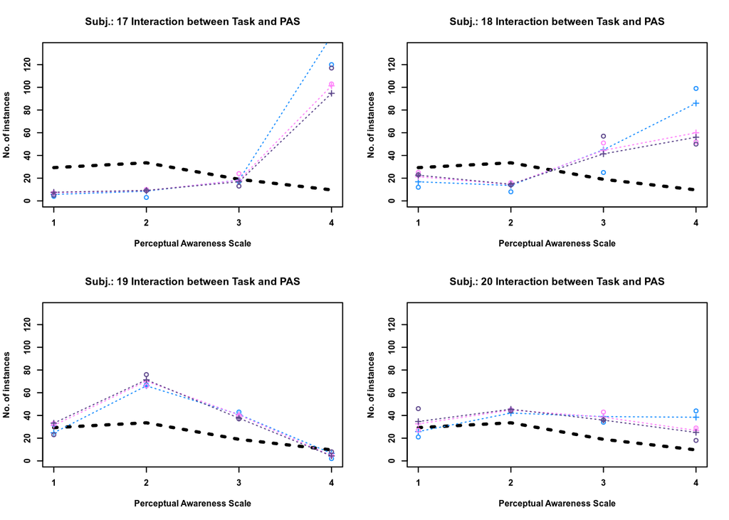

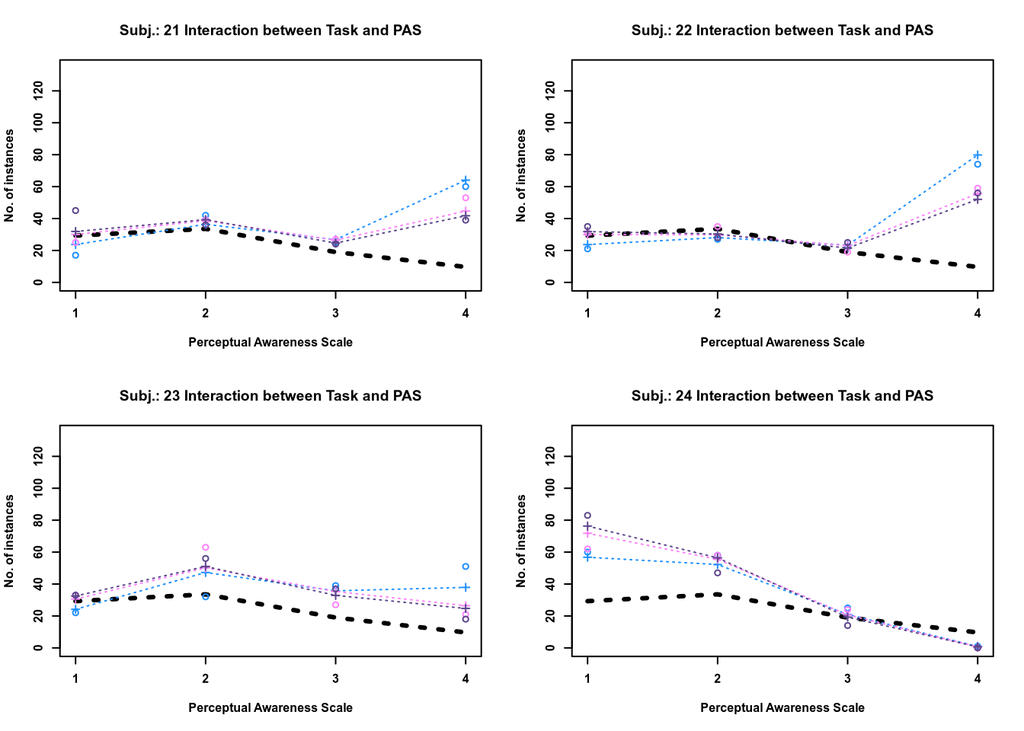

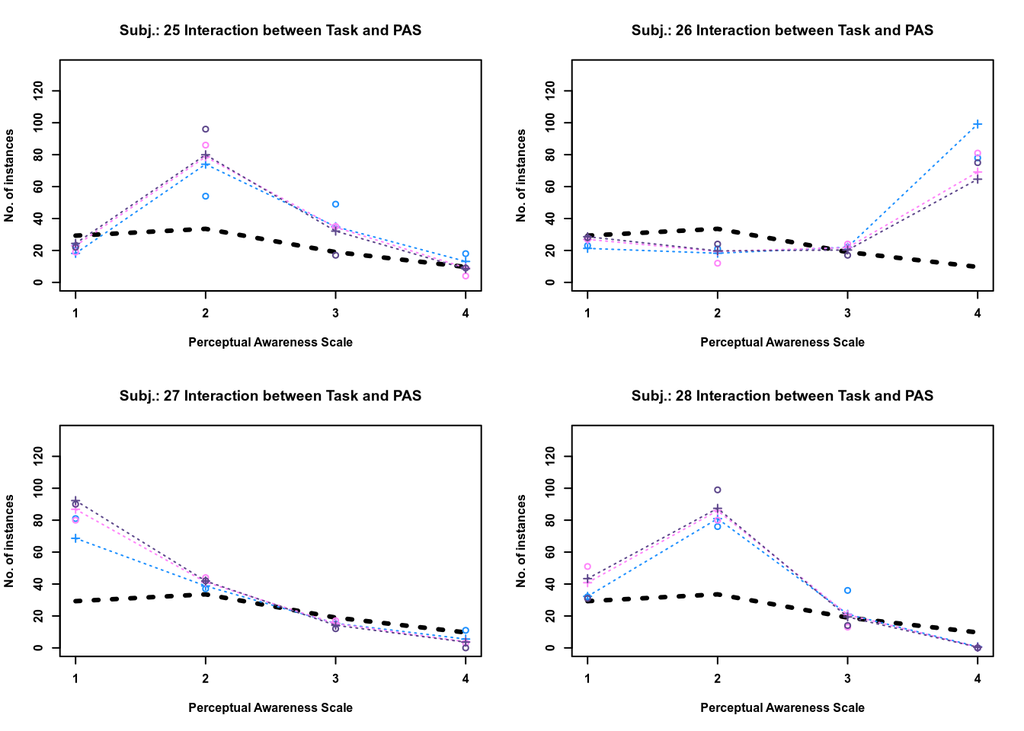

```r
# vi.
set.seed(1)
subjects <- 1:29
par(mfrow=c(2, 2), font.axis=2, font.lab=2, cex=0.5)
cols <- colours()[sample(1:length(colours()), nlevels(data.count$task))]
pm <- multilevel.poisson.bobyqa

for(subject.index in 1:length(subjects))
{
    subject <- levels(data.count$subject)[subject.index]
    subject.name <- subject
    subject.data <- data.count[data.count$subject == subject,]
    plot(count ~ as.numeric(pas), data=data.count, type='n', xaxt='n',
        xlab='Perceptual Awareness Scale', ylab='No. of instances',
        main=paste('Subj.:', subject.name , 'Interaction between Task and PAS'))
    axis(1, 1:4, 1:4)
    group.vector <- c(fixef(pm)[1], sum(fixef(pm)[c(1, 2)]), sum(fixef(pm)[c(1, 3)]), sum(fixef(pm)[c(1, 4)]))
    lines(1:4, exp(group.vector), lwd=3, lty=3)
    if(subject.index == 1) legend('topright', legend=c(paste('Fitted', levels(data.count$task))
                                                       , 'First-level',
                                                       paste('Obs.', levels(data.count$task))),
                                  lwd=c(1,1,1,3,NA,NA,NA),
                                  col=c(cols, 'black', cols), lty=3,
                                  pch=c(3,3,3,NA,1,1,1))
    for(task.index in 1:nlevels(subject.data$task))
    {
        task <- levels(subject.data$task)[task.index]
        points(subject.data$pas[subject.data$task == task],
               subject.data$count[subject.data$task == task],
               col=cols[task.index])
        pas.vector <- numeric(4)
        for(pas in 1:nlevels(subject.data$pas))
        {
            if(task == 'singles' & pas == 1) pas.vector[pas] <- fixef(pm)[1] + ranef(pm)$subject[subject.index, 1]
            if(task == 'singles' & pas == 2) pas.vector[pas] <- sum(fixef(pm)[1:2]) + sum(ranef(pm)$subject[subject.index, 1:2])
            if(task == 'singles' & pas == 3) pas.vector[pas] <- sum(fixef(pm)[c(1, 3)]) + sum(ranef(pm)$subject[subject.index, c(1, 3)])
            if(task == 'singles' & pas == 4) pas.vector[pas] <- sum(fixef(pm)[c(1, 4)]) + sum(ranef(pm)$subject[subject.index, c(1, 4)])
            ## change below

            if(task == 'pairs' & pas == 1) pas.vector[pas] <- sum(fixef(pm)[c(1,5)]) + ranef(pm)$subject[subject.index, 1]
            if(task == 'pairs' & pas == 2) pas.vector[pas] <- sum(fixef(pm)[c(1,2,5,7)]) + sum(ranef(pm)$subject[subject.index, 1:2])
            if(task == 'pairs' & pas == 3) pas.vector[pas] <- sum(fixef(pm)[c(1,3,5,8)]) + sum(ranef(pm)$subject[subject.index, c(1, 3)])
            if(task == 'pairs' & pas == 4) pas.vector[pas] <- sum(fixef(pm)[c(1,4,5,9)]) + sum(ranef(pm)$subject[subject.index, c(1, 4)])
            #
            if(task == 'quadruplet' & pas == 1) pas.vector[pas] <- sum(fixef(pm)[c(1,6)]) + ranef(pm)$subject[subject.index, 1]
            if(task == 'quadruplet' & pas == 2) pas.vector[pas] <- sum(fixef(pm)[c(1,2,6,10)]) + sum(ranef(pm)$subject[subject.index, 1:2])
            if(task == 'quadruplet' & pas == 3) pas.vector[pas] <- sum(fixef(pm)[c(1,3,6,11)]) + sum(ranef(pm)$subject[subject.index, c(1, 3)])
            if(task == 'quadruplet' & pas == 4) pas.vector[pas] <- sum(fixef(pm)[c(1,4,6, 12)]) + sum(ranef(pm)$subject[subject.index, c(1, 4)])


        }
        lines(1:4, exp(pas.vector),  lty=3, col=cols[task.index])
        points(1:4, exp(pas.vector), pch=3, col=cols[task.index])
    }

}
```

```r
# vii.
print('Answer vii.: ')
```

```
## [1] "Answer vii.: "
```

[figure not shown]